# Impact of severe weather events on public health and the economy in the United States

Srikar Murali

October 15, 2017

## Load Data

```r
data <- read.csv('C:/Users/srika/Documents/R/John Hopkins/Reproducible Research/repdata%2Fdata%2FStormData.csv')
str(data)
```

```
## 'data.frame':    902297 obs. of  37 variables:
##  $ STATE__   : num  1 1 1 1 1 1 1 1 1 1 ...
##  $ BGN_DATE  : Factor w/ 16335 levels "1/1/1966 0:00:00",..: 6523 6523 4242 11116 2224 2224 2260 383 3980 3980 ...
##  $ BGN_TIME  : Factor w/ 3608 levels "00:00:00 AM",..: 272 287 2705 1683 2584 3186 242 1683 3186 3186 ...
##  $ TIME_ZONE : Factor w/ 22 levels "ADT","AKS","AST",..: 7 7 7 7 7 7 7 7 7 7 ...
##  $ COUNTY    : num  97 3 57 89 43 77 9 123 125 57 ...
##  $ COUNTYNAME: Factor w/ 29601 levels "","5NM E OF MACKINAC BRIDGE TO PRESQUE ISLE LT MI",..: 13513 1873 4598 10592 4372 10094 1973 23873 24418 4598 ...
##  $ STATE     : Factor w/ 72 levels "AK","AL","AM",..: 2 2 2 2 2 2 2 2 2 2 ...
##  $ EVTYPE    : Factor w/ 985 levels "   HIGH SURF ADVISORY",..: 834 834 834 834 834 834 834 834 834 834 ...
##  $ BGN_RANGE : num  0 0 0 0 0 0 0 0 0 0 ...
##  $ BGN_AZI   : Factor w/ 35 levels "","  N"," NW",..: 1 1 1 1 1 1 1 1 1 1 ...
##  $ BGN_LOCATI: Factor w/ 54429 levels "","- 1 N Albion",..: 1 1 1 1 1 1 1 1 1 1 ...
##  $ END_DATE  : Factor w/ 6663 levels "","1/1/1993 0:00:00",..: 1 1 1 1 1 1 1 1 1 1 ...
##  $ END_TIME  : Factor w/ 3647 levels ""," 0900CST",..: 1 1 1 1 1 1 1 1 1 1 ...
##  $ COUNTY_END: num  0 0 0 0 0 0 0 0 0 0 ...
```

[output cut: 23 more lines]

## Process Data

There are 7 variables we are interested regarding the two questions. They are:-

EVTYPE as a measure of event type (e.g. tornado, flood, etc.) FATALITIES as a measure of harm to human health INJURIES as a measure of harm to human health PROPDMG as a measure of property damage and hence economic damage in USD PROPDMGEXP as a measure of magnitude of property damage (e.g. thousands, millions USD, etc.) CROPDMG as a measure of crop damage and hence economic damage in USD CROPDMGEXP as a measure of magnitude of crop damage (e.g. thousands, millions USD, etc.)

```r
requiredData <- select(data, BGN_DATE,EVTYPE, FATALITIES, INJURIES, PROPDMG, PROPDMGEXP, CROPDMG, CROPDMGEXP)
requiredData$byYear <- as.numeric(format(as.Date(requiredData$BGN_DATE, format = "%m/%d/%Y %H:%M:%S"), "%Y"))
```

## Most harm to humans and economy

[figure not shown]

```r
stormHist <- ggplot(requiredData, aes(byYear)) +
  geom_histogram(bins = 25, fill = 'blue') +
  ggtitle('Weather Fatilities by Year')
stormHist
```

```r
fatalities <- requiredData %>%
  group_by(EVTYPE) %>%
  summarise(TotalFatilities = sum(FATALITIES)) %>%
  arrange(desc(TotalFatilities)) %>%
  top_n(10)
```

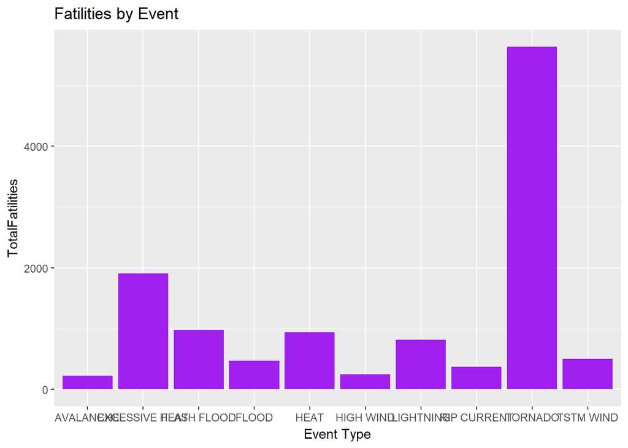

```r
eventFatalities <- ggplot(fatalities, aes(x = EVTYPE, y = TotalFatilities)) +
  geom_bar(stat = 'identity',fill = 'purple') +
  xlab('Event Type') +
  ggtitle('Fatilities by Event')
eventFatalities
```

```r
injuries <- requiredData %>%
  group_by(EVTYPE) %>%
  summarise(TotalInjured = sum(INJURIES)) %>%
  arrange(desc(TotalInjured)) %>%
  top_n(10)
```

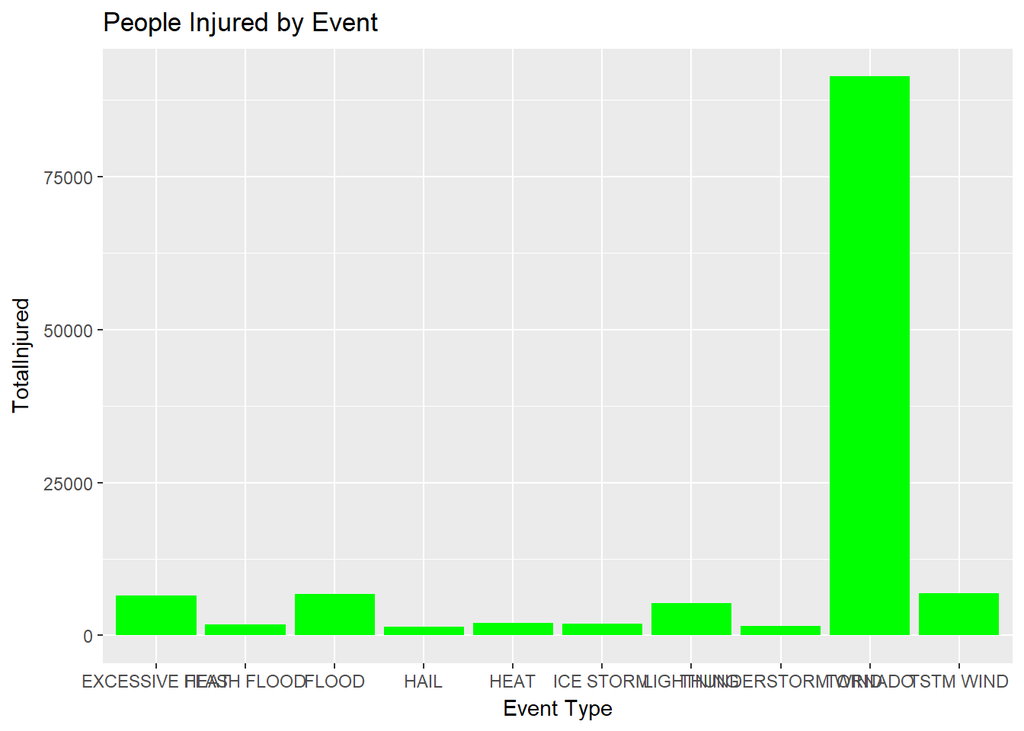

```r
eventInjured <- ggplot(injuries, aes(x = EVTYPE, y = TotalInjured)) +
  geom_bar(stat = 'identity', fill = 'green') +
  xlab('Event Type') +
  ggtitle('People Injured by Event')
eventInjured
```

As you can see from the analysis, TORNADO caused the most fatalities and most injuries. FLOOD caused the most property damage. DROUGHT caused the most crop damange, while FLOOD caused the most overall economic damage.

## Most Harm to Crops and Property

```r
unique(requiredData$PROPDMGEXP)
```

```
##  [1] K M   B m + 0 5 6 ? 4 2 3 h 7 H - 1 8
## Levels:  - ? + 0 1 2 3 4 5 6 7 8 B h H K m M
```

```r
unique(requiredData$CROPDMGEXP)
```

```
## [1]   M K m B ? 0 k 2
## Levels:  ? 0 2 B k K m M
```

```r
requiredData$PROPDMGEXP <- as.character(requiredData$PROPDMGEXP)
requiredData$PROPDMGEXP <- gsub("\\-|\\+|\\?","0",requiredData$PROPDMGEXP)
requiredData$PROPDMGEXP <- gsub('B|b', '9', requiredData$PROPDMGEXP)
requiredData$PROPDMGEXP <- gsub('M|m', '6', requiredData$PROPDMGEXP)
requiredData$PROPDMGEXP <- gsub('K|k', '3', requiredData$PROPDMGEXP)
requiredData$PROPDMGEXP <- gsub('H|h', '2', requiredData$PROPDMGEXP)
requiredData$PROPDMGEXP <- as.numeric(requiredData$PROPDMGEXP)
requiredData$PROPDMGEXP[is.na(requiredData$PROPDMGEXP)] <- 0
requiredData$TrueDamage <- requiredData$PROPDMG * 10^requiredData$PROPDMGEXP

propertyDamage <- aggregate(TrueDamage ~ EVTYPE, data = requiredData, sum)
propertyDamage <- propertyDamage[order(-propertyDamage$TrueDamage),]
propertyDamage <- propertyDamage[1:10,]


requiredData$CROPDMGEXP <- as.character(requiredData$CROPDMGEXP)
requiredData$CROPDMGEXP <- gsub("\\-|\\+|\\?","0",requiredData$CROPDMGEXP)
requiredData$CROPDMGEXP <- gsub('B|b', '9', requiredData$CROPDMGEXP)
requiredData$CROPDMGEXP <- gsub('M|m', '6', requiredData$CROPDMGEXP)
requiredData$CROPDMGEXP <- gsub('K|k', '3', requiredData$CROPDMGEXP)
requiredData$CROPDMGEXP <- gsub('H|h', '2', requiredData$CROPDMGEXP)
requiredData$CROPDMGEXP <- as.numeric(requiredData$CROPDMGEXP)
requiredData$CROPDMGEXP[is.na(requiredData$CROPDMGEXP)] <- 0
requiredData$TrueCropDamage <- requiredData$CROPDMG * 10^requiredData$CROPDMGEXP

cropDamage <- aggregate(TrueCropDamage ~ EVTYPE, data = requiredData, sum)
cropDamage <- cropDamage[order(-cropDamage$TrueCropDamage),]
cropDamage <- cropDamage[1:10,]

damageCombined <- aggregate(TrueDamage + TrueCropDamage ~ EVTYPE, data = requiredData, sum)
names(damageCombined)[2] <- 'Total_Damage'
damageCombined <- damageCombined %>%
  arrange(desc(Total_Damage)) %>%
  top_n(10)
propertyDamage
```

```
##                EVTYPE   TrueDamage
## 170             FLOOD 144657709807
## 411 HURRICANE/TYPHOON  69305840000
## 834           TORNADO  56947380677
## 670       STORM SURGE  43323536000
## 153       FLASH FLOOD  16822673979
## 244              HAIL  15735267513
## 402         HURRICANE  11868319010
## 848    TROPICAL STORM   7703890550
## 972      WINTER STORM   6688497251
## 359         HIGH WIND   5270046295
```

```r
cropDamage
```

```
##                EVTYPE TrueCropDamage
## 95            DROUGHT    13972566000
## 170             FLOOD     5661968450
## 590       RIVER FLOOD     5029459000
## 427         ICE STORM     5022113500
## 244              HAIL     3025954473
## 402         HURRICANE     2741910000
## 411 HURRICANE/TYPHOON     2607872800
## 153       FLASH FLOOD     1421317100
## 140      EXTREME COLD     1292973000
## 212      FROST/FREEZE     1094086000
```

```r
damageCombined
```

```
##               EVTYPE Total_Damage
## 1              FLOOD 150319678257
## 2  HURRICANE/TYPHOON  71913712800
## 3            TORNADO  57362333947
## 4        STORM SURGE  43323541000
## 5               HAIL  18761221986
## 6        FLASH FLOOD  18243991079
## 7            DROUGHT  15018672000
## 8          HURRICANE  14610229010
## 9        RIVER FLOOD  10148404500
## 10         ICE STORM   8967041360
```

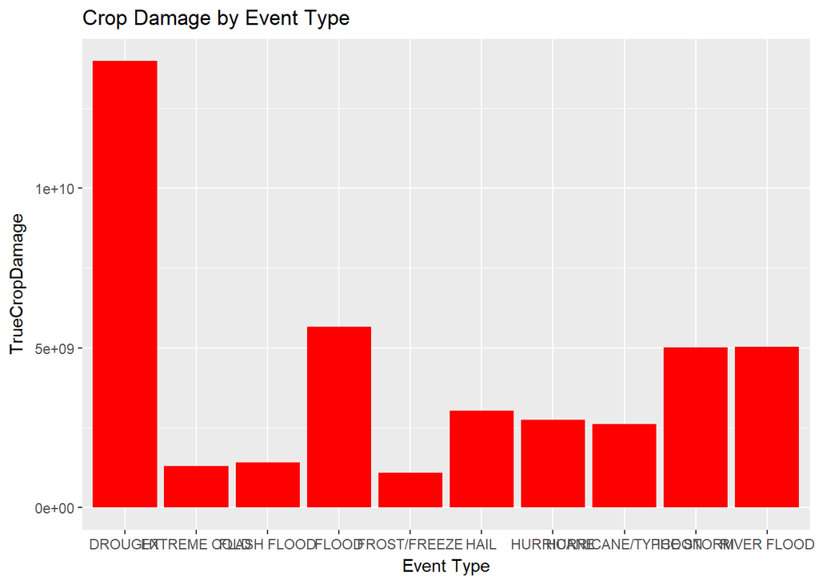

```r
par(mfrow = c(1,3))
DamagetoCrops <- ggplot(cropDamage, aes(x = EVTYPE, y = TrueCropDamage)) +
  geom_bar(stat = 'identity', fill = 'red') +
  xlab('Event Type') +
  ggtitle('Crop Damage by Event Type')
damagetoProperty <- ggplot(propertyDamage, aes(x = EVTYPE, y = TrueDamage)) +
  geom_bar(stat = 'identity', fill = 'red') +
  xlab('Event Type') +
  ggtitle('Property Damage by Event Type')

fullDamage <- ggplot(damageCombined, aes(x = EVTYPE, y = Total_Damage)) +
  geom_bar(stat = 'identity', fill = 'red') +
  xlab('Event Type') +
  ggtitle('Total Damage by Event Type')

DamagetoCrops
```

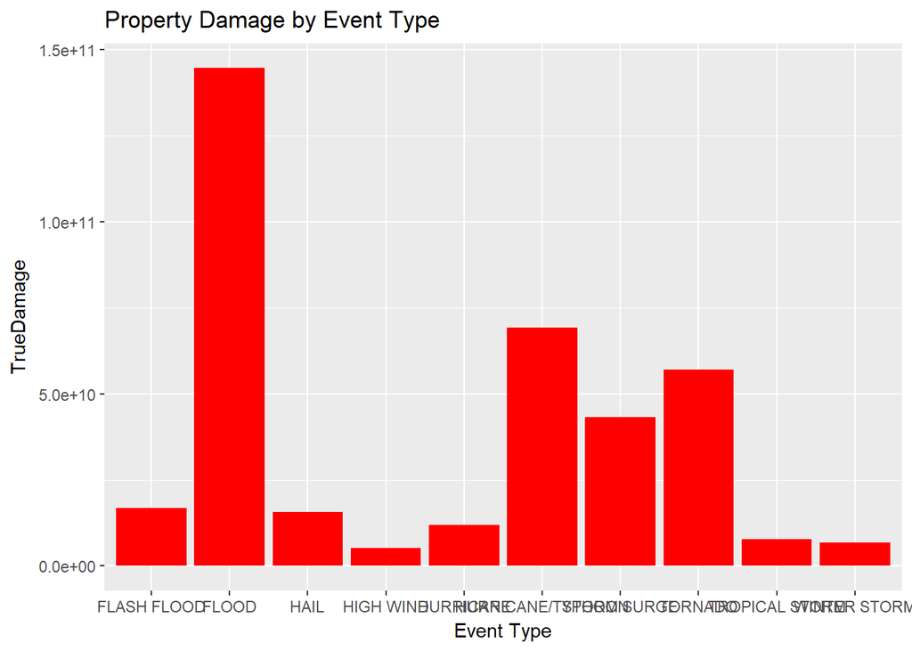

```r
damagetoProperty
```

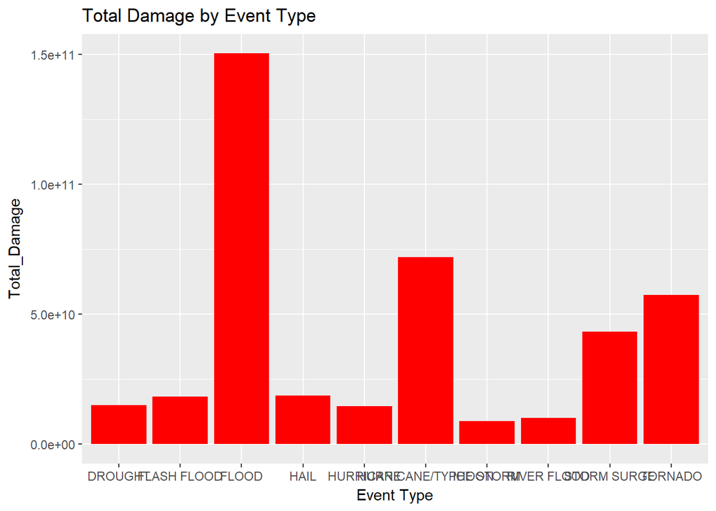

```r
fullDamage
```

As you can see from the analysis, TORNADO caused the most fatalities and most injuries. FLOOD caused the most property damage. DROUGHT caused the most crop damange, while FLOOD caused the most overall economic damage.